# Pipeline Avanzata: BAM & Forecasting Ricorsivo

Analisi Clorofilla Alto Adriatico

Pietro & Gemini

2025-12-10

# 1 Introduzione

Questa pipeline implementa un approccio di modellazione avanzata per la previsione della Clorofilla nell’Alto Adriatico. Vengono confrontati due approcci: 1. **BAM Spazio-Temporale (Standard):** Modello additivo generalizzato per Big Data. 2. **BAM Autoregressivo (AR):** Modello dinamico con forecasting ricorsivo a più step.

# 2 Setup e Librerie

Caricamento delle librerie necessarie per la manipolazione dati, la modellazione statistica (`mgcv`) e la visualizzazione.

```r
library(tidyverse)  # Include ggplot2, dplyr, tidyr
library(mgcv)       # Modelli GAM e BAM (Generalized Additive Models)
library(lubridate)  # Gestione Date
library(parallel)   # Per detectCores
library(gridExtra)  # Per affiancare i plot (grid.arrange)
library(viridis)    # Scale di colori per mappe
```

# 3 Caricamento e Pre-processing

## 3.1 Importazione Dati

Carichiamo il dataset “mergiato” contenente le variabili biogeochimiche e fisiche.

```r
path_dataset <- "/Users/leomarcellopoli/Documents/Nonparametric/Project/Non-parametric-Statistics-2025-2026/dataset/dataset_MERGIATO"
df <- read.csv(path_dataset)

# Rilevamento core per eventuale parallelizzazione (OpenMP)
n_cores <- detectCores() - 1
cat("Core rilevati per BAM:", n_cores, "\n")
```

```
## Core rilevati per BAM: 7
```

## 3.2 Filtro Spaziale e Selezione Locazioni

Per garantire la robustezza delle serie storiche, applichiamo un filtro rigoroso: manteniamo solo le stazioni (pixel) che hanno una serie temporale completa (366 giorni) e valori di clorofilla consistenti.

```r
# 1. Calcola la media per visualizzazione rapida
mappa_media <- df %>%
  group_by(Lon, Lat) %>%
  summarise(Mean_Chl = mean(Chl, na.rm = TRUE), .groups = 'drop')

# 2. Filtro: Mantieni solo stazioni con dati completi
posizioni_target <- df %>%
  group_by(Lat, Lon) %>%
  summarise(
    giorni_sopra_soglia = sum(Chl > 0.1, na.rm = TRUE),
    .groups = 'drop'
  ) %>%
  mutate(loc_id = row_number()) %>%
  filter(giorni_sopra_soglia >= 366) # Richiede serie completa

cat("Numero di posizioni filtrate (dati completi):", nrow(posizioni_target), "\n")
```

```
## Numero di posizioni filtrate (dati completi): 291
```

## 3.3 Feature Engineering Temporale

Uniamo le posizioni filtrate al dataset originale e creiamo le variabili temporali necessarie per i modelli (Giorno dell’anno, Tempo numerico).

```r
data_proc <- df %>%
  inner_join(posizioni_target, by = c("Lat", "Lon")) %>%
  mutate(
    Date = ymd(Date),
    doy = yday(Date),               # Giorno dell'anno (1-366) per stagionalità
    time_numeric = as.numeric(Date) # Tempo continuo per trend
  ) %>%
  arrange(Date) # Ordinamento fondamentale per i modelli temporali
```

# 4 Modello 1: BAM Spazio-Temporale (Base)

Questo primo approccio utilizza un modello additivo generalizzato per Big Data (`bam`) che modella la clorofilla in funzione dello spazio, del tempo e delle covariate ambientali contemporanee.

## 4.1 Split Training/Validation

Utilizziamo gli ultimi 3 giorni della serie temporale come set di validazione per testare la capacità predittiva.

```r
num_days2predict <- 3
max_date <- max(data_proc$Date)
cutoff_date <- max_date - days(num_days2predict)

train_set <- data_proc %>% filter(Date <= cutoff_date)
val_set   <- data_proc %>% filter(Date > cutoff_date)

cat("Training Set:", nrow(train_set), "righe\n")
```

```
## Training Set: 105633 righe
```

```r
cat("Validation Set:", nrow(val_set), "righe\n")
```

```
## Validation Set: 873 righe
```

## 4.2 Addestramento Modello

La struttura del modello include: * Interazione tensoriale spazio-tempo `te(Lon, Lat, time)`. * Spline ciclica per la stagionalità `s(doy)`. * Effetti non lineari delle covariate fisiche (`Temp`, `Salinity`, `MLD`, `Solar_Flux`).

```r
cat("Inizio addestramento BAM standard...\n")
```

```
## Inizio addestramento BAM standard...
```

```r
model_bam <- bam(
  Chl ~
    # Interazione Spazio-Tempo
    te(Lon, Lat, time_numeric, d=c(2,1), k=c(15, 15)) +

    # Stagionalità Ciclica
    s(doy, bs = "cc", k = 10) +

    # Effetti Covariate
    s(Temp, k=8) + s(Salinity, k=8) + s(MLD, k=8) + s(Solar_Flux, k=8),

  data = train_set,
  method = "fREML",        # Ottimizzazione veloce
  discrete = TRUE,         # Discretizzazione per performance
  nthreads = 1,            # Set a 1 per compatibilità
  chunk.size = 10000,
  family = Gamma(link="log") # Distribuzione Gamma (dati positivi asimmetrici)
)

cat("Modello BAM standard addestrato.\n")
```

```
## Modello BAM standard addestrato.
```

## 4.3 Valutazione Performance

Calcoliamo RMSE e MAE sul validation set.

```r
preds <- predict(model_bam, newdata = val_set, type = "response", se.fit = TRUE)

val_results <- val_set %>%
  mutate(
    Predicted_Chl = preds$fit,
    SE = preds$se.fit,
    Lower_CI = Predicted_Chl - 1.96 * SE,
    Upper_CI = Predicted_Chl + 1.96 * SE
  )

rmse <- sqrt(mean((val_results$Chl - val_results$Predicted_Chl)^2))
mae <- mean(abs(val_results$Chl - val_results$Predicted_Chl))

cat("Risultati Modello 1 (Standard):\n")
```

```
## Risultati Modello 1 (Standard):
```

```r
cat("RMSE:", round(rmse, 4), "\n")
```

```
## RMSE: 1.7813
```

```r
cat("MAE:", round(mae, 4), "\n")
```

```
## MAE: 1.2924
```

# 5 Modello 2: BAM Autoregressivo (AR)

Per migliorare le prestazioni a breve termine, introduciamo componenti autoregressive: la clorofilla di oggi dipende fortemente dalla clorofilla di ieri.

## 5.1 Creazione Lag (Variabili Ritardate)

Generiamo le variabili ritardate ($t-1$) per la clorofilla e per i predittori fisici.

```r
data_lagged <- data_proc %>%
  arrange(Lon, Lat, Date) %>%
  group_by(Lon, Lat) %>%
  mutate(
    Chl_lag1      = lag(Chl, 1),
    Temp_lag1     = lag(Temp, 1),
    Salinity_lag1 = lag(Salinity, 1),
    MLD_lag1      = lag(MLD, 1),
    Solar_lag1    = lag(Solar_Flux, 1)
  ) %>%
  ungroup() %>%
  drop_na(Chl_lag1, Temp_lag1, Salinity_lag1, MLD_lag1, Solar_lag1)

# Nuovo Split
train_set_ar <- data_lagged %>% filter(Date <= cutoff_date)
val_set_ar   <- data_lagged %>% filter(Date > cutoff_date)

cat("Training Set AR:", nrow(train_set_ar), "righe\n")
```

```
## Training Set AR: 105342 righe
```

## 5.2 Addestramento Modello AR

Il modello include ora `s(Chl_lag1)` come predittore principale, insieme ai lag delle variabili ambientali e alle componenti spazio-temporali pure.

```r
# Pesi per gestire l'eteroschedasticità (facoltativo ma utile)
weights_vec <- (exp(train_set_ar$Chl * 0.3) - 1) * 0.5

cat("Inizio addestramento BAM Autoregressivo...\n")
```

```
## Inizio addestramento BAM Autoregressivo...
```

```r
model_bam_ar <- bam(
  Chl ~
    # Componente Autoregressiva (Fondamentale)
    s(Chl_lag1, k=20) +

    # Autoregressione Covariate Ambientali
    s(Temp_lag1, k=20) +
    # (Altre covariate commentate per semplificazione)

    # Componenti Spazio-Temporali
    te(Lon, Lat, doy, d=c(2,1), bs=c("tp", "cc"), k=c(20, 20)),

  data = train_set_ar,
  method = "fREML",
  discrete = TRUE,
  nthreads = 1,
  chunk.size = 10000,
  weights = weights_vec,
  family = tw(link = "log") # Tweedie: robusta per dati con skewness
)

cat("Modello BAM AR addestrato.\n")
```

```
## Modello BAM AR addestrato.
```

## 5.3 Forecasting Ricorsivo (Step-by-Step)

Simuliamo una previsione reale a 3 giorni: il modello prevede il giorno $t+1$, e questa previsione viene usata come input (lag) per prevedere il giorno $t+2$, e così via.

```r
# Inizializzazione
last_observed_day <- train_set_ar %>% filter(Date == max(Date))
forecast_results <- list()
input_data <- last_observed_day

cat("Avvio previsione ricorsiva per", num_days2predict, "giorni...\n")
```

```
## Avvio previsione ricorsiva per 3 giorni...
```

```r
for (i in 1:num_days2predict) {

  # 1. Aggiorna Data Target
  target_date <- unique(last_observed_day$Date) + days(i)

  input_data <- input_data %>%
    mutate(
      Date = target_date,
      doy = yday(target_date),
      time_numeric = as.numeric(target_date)
    )

  # 2. Predizione
  prediction <- predict(model_bam_ar, newdata = input_data, type = "response")

  # 3. Salvataggio
  forecast_results[[i]] <- input_data %>%
    mutate(
      Pred_Chl = prediction,
      Forecast_Day = i
    ) %>%
    select(Date, Lon, Lat, Pred_Chl, Forecast_Day)

  # 4. Aggiornamento Ricorsivo (La predizione diventa il lag di domani)
  input_data <- input_data %>%
    mutate(
      Chl_lag1 = prediction
      # Nota: Temp_lag1 rimane costante (persistenza)
    )
}

forecast_final <- bind_rows(forecast_results)
```

# 6 Confronto Finale e Visualizzazione

Uniamo le previsioni ricorsive ai dati reali del validation set per valutare l’accuratezza su più giorni.

```r
# Join Dati Reali vs Predetti
comparison <- val_set_ar %>%
  select(Date, Lon, Lat, Chl_Real = Chl) %>%
  inner_join(forecast_final, by = c("Date", "Lon", "Lat"))

# Calcolo Metriche
metrics_ar <- comparison %>%
  group_by(Forecast_Day) %>%
  summarise(
    RMSE = sqrt(mean((Chl_Real - Pred_Chl)^2)),
    MAE = mean(abs(Chl_Real - Pred_Chl))
  )

print("Metriche Modello AR per orizzonte temporale:")
```

```
## [1] "Metriche Modello AR per orizzonte temporale:"
```

```r
print(metrics_ar)
```

```
## # A tibble: 3 × 3
##   Forecast_Day  RMSE   MAE
##          <int> <dbl> <dbl>
## 1            1 1.56  1.07
## 2            2 2.02  1.40
## 3            3 0.945 0.691
```

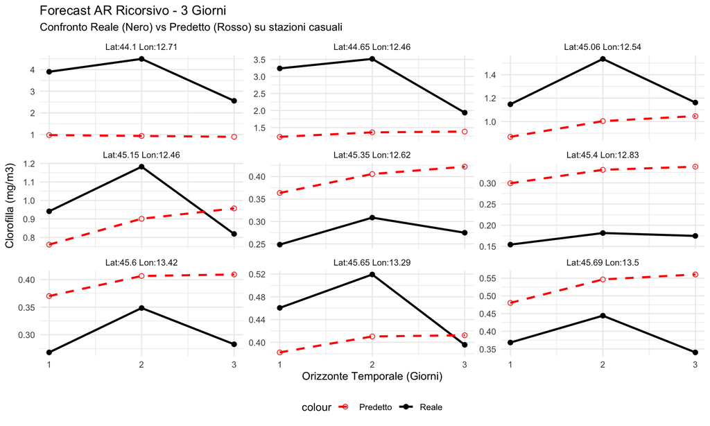

```r
# --- Plot Campione Casuale (9 Stazioni) ---
set.seed(1)
n_sample <- 9
sampled_locs <- comparison %>% select(Lat, Lon) %>% distinct() %>% sample_n(min(n_sample, nrow(.)))

plot_subset <- comparison %>%
  inner_join(sampled_locs, by = c("Lat", "Lon")) %>%
  mutate(Location_Label = paste0("Lat:", round(Lat, 2), " Lon:", round(Lon, 2)))

ggplot(plot_subset, aes(x = Forecast_Day)) +
  # Linea Reale
  geom_line(aes(y = Chl_Real, color = "Reale"), linewidth = 1) +
  geom_point(aes(y = Chl_Real, color = "Reale"), size = 2) +

  # Linea Predetta
  geom_line(aes(y = Pred_Chl, color = "Predetto"), linetype = "dashed", linewidth = 1) +
  geom_point(aes(y = Pred_Chl, color = "Predetto"), shape = 1, size = 2) +

  facet_wrap(~Location_Label, scales = "free_y", ncol = 3) +
  scale_color_manual(values = c("Reale" = "black", "Predetto" = "red")) +
  scale_x_continuous(breaks = 1:num_days2predict) +
  labs(
    title = paste("Forecast AR Ricorsivo -", num_days2predict, "Giorni"),
    subtitle = "Confronto Reale (Nero) vs Predetto (Rosso) su stazioni casuali",
    y = "Clorofilla (mg/m3)", x = "Orizzonte Temporale (Giorni)"
  ) +
  theme_minimal() + theme(legend.position = "bottom")
```